# SEM04

ROSENDO RAMIRO ENRIQUE SANCHEZ PEREZ

20 de diciembre de 2024

[figure not shown]

Maestría en Inteligencia Artificial para la Transformación Digital

Lenguajes de ciencia de datos avanzado (2025-01)

Tercer cuatrimestre

Unidad 4

Alumno: Rosendo Ramiro Enrique Sánchez Pérez

Tutor: Dr. Jonás Velasco Álvarez

# Actividad 4. 1

```r
library(tidyverse)
```

```r
# Cargar las librerías
library(dplyr)
library(lubridate)
library(tidyr)
```

```r
data <- read.csv("llamadas_911_2022_s1.csv", stringsAsFactors = FALSE)
```

Si desea ocultar el código click en Hide

## Ejercicio 1

Agrupa los incidentes por mes y alcaldía, y calcula el número promedio de incidentes por categoría.

```r
for (i in 1:3) {

  # Cargar el archivo CSV
  # Carga el archivo correspondiente
  if (i==1) {
    data <- read.csv("llamadas_911_2021_s1.csv", stringsAsFactors = FALSE)
    titulo ="Llamadas al 911 durante el primer semestre de 2021"
  } else {if (i==2){
    data <- read.csv("llamadas_911_2021_s2.csv", stringsAsFactors = FALSE)
    titulo ="Llamadas al 911 durante el segundo semestre de 2021"}
    else {
      data <- read.csv("llamadas_911_2022_s1.csv", stringsAsFactors = FALSE)
      titulo ="Llamadas al 911 durante el primer semestre de 2022"
    }
  }


  # Agrupar por incidente_c4, mes y alcaldía, y calcular el promedio de incidentes

  resultados <- data %>%

  #  group_by(incidente_c4, mesdecreacion, alcaldia) %>%
    group_by(clasif, mesnum, mesdecreacion, alcaldia) %>%
    summarise(promedio_incidentes = n() / n_distinct(incidente_c4), .groups = "drop")

  # Mostrar los resultados
  cat(titulo)
  cat("\n")

  print(n=30, resultados)

  # Calcular el promedio de incidentes por categoría y mostrarlo
  promedio_por_categoria <- data %>%
    group_by(clasif) %>%
   summarise(promedio_incidentes = n() / n_distinct(clasif), .groups = "drop")

  # Mostrar el promedio de incidentes por categoría
  print(" Mostrar el promedio de incidentes por categoría")
  print(promedio_por_categoria)
  cat("\n\n")

}
```

```
## Llamadas al 911 durante el primer semestre de 2021
## # A tibble: 635 × 5
##    clasif mesnum mesdecreacion alcaldia               promedio_incidentes
##    <chr>   <int> <chr>         <chr>                                <dbl>
##  1 DELITO      1 Enero         ALVARO OBREGON                        61.3
##  2 DELITO      1 Enero         AZCAPOTZALCO                          46.2
##  3 DELITO      1 Enero         BENITO JUAREZ                         45.9
##  4 DELITO      1 Enero         COYOACAN                              48.6
##  5 DELITO      1 Enero         CUAJIMALPA DE MORELOS                 15
##  6 DELITO      1 Enero         CUAUHTEMOC                            62.7
##  7 DELITO      1 Enero         GUSTAVO A. MADERO                    120.
##  8 DELITO      1 Enero         IZTACALCO                             47.5
##  9 DELITO      1 Enero         IZTAPALAPA                           156.
## 10 DELITO      1 Enero         LA MAGDALENA CONTRERAS                27.2
## 11 DELITO      1 Enero         MIGUEL HIDALGO                        40.4
```

[output cut: 125 more lines]

Si desea ocultar el código click en Hide

### Conclusiones del ejercicio 1

Como se aprecia los resultados son los mismos que ya se habían analizado en la actividad 3.1 Las cifras son muy repetitivas por mes y alcaldía así como por la clasificación de incidente en lo que encabezan son servicio y delito. Solo que ahora con la ventaja que se muestran en HTML.

```r
library(tidyverse)
```

```r
# Cargar las librerías
library(dplyr)
library(lubridate)
library(tidyr)
```

## Ejercicio 2

Identifica el día de la semana con más incidentes y determinar el total de llamadas para ese día.

```r
for (i in 1:3) {

  # Cargar el archivo CSV
  # Carga el archivo correspondiente
  if (i==1) {
    data <- read.csv("llamadas_911_2021_s1.csv", stringsAsFactors = FALSE)
    titulo ="Llamadas al 911 durante el primer semestre de 2021"
  } else {if (i==2){
    data <- read.csv("llamadas_911_2021_s2.csv", stringsAsFactors = FALSE)
    titulo ="Llamadas al 911 durante el segundo semestre de 2021"}
    else {
      data <- read.csv("llamadas_911_2022_s1.csv", stringsAsFactors = FALSE)
      titulo ="Llamadas al 911 durante el primer semestre de 2022"
    }
  }



  # Contar el total de llamadas por día
  dias_conteo <- data %>%
   group_by(dia_incidente) %>%
   summarise(total_llamadas = n(), .groups = "drop")

  # Identificar el día con más incidentes
  dia_max_incidentes <- dias_conteo %>%
   filter(total_llamadas == max(total_llamadas))

  # Mostrar el resultado
  cat(titulo)
  cat("\n")
  print(dia_max_incidentes)
  cat("\n\n")

}
```

```
## Llamadas al 911 durante el primer semestre de 2021
## # A tibble: 1 × 2
##   dia_incidente total_llamadas
##   <chr>                  <int>
## 1 s�bado                134065
##
##
## Llamadas al 911 durante el segundo semestre de 2021
## # A tibble: 1 × 2
##   dia_incidente total_llamadas
##   <chr>                  <int>
## 1 domingo               120470
##
##
## Llamadas al 911 durante el primer semestre de 2022
## # A tibble: 1 × 2
##   dia_incidente total_llamadas
##   <chr>                  <int>
## 1 s�bado                 75884
```

### Conclusiones del ejercicio 2

Como se mencionó en la actividad 3.1 el comportamiento para el día de la semana con más incidentes y el total de llamadas para ese día se manifiesta para el fin de semana en los tres semestres analizados, teniendo mayor incidencia en el sábado que es el que obtiene el mayor número de llamadas en dos de los tres semestres analizados. Ahora con R Markdown el análisis se presenta con mejor visualización con HTML

```r
library(dplyr)
library(lubridate)
library(tidyr)
```

## Ejercicio 3

Crea un análisis temporal que muestre la distribución de incidentes por hora del día para las categorías “DELITO”, “EMERGENCIA” y “URGENCIA MÉDICA”. Utiliza gráficos adecuados para el análisis.

```
## Llamadas al 911 durante el primer semestre de 2021
## # A tibble: 72 × 3
##     hora clasif            cantidad
##    <dbl> <chr>                <int>
##  1     0 DELITO                7915
##  2     0 EMERGENCIA            1472
##  3     0 URGENCIAS MEDICAS     3296
##  4     1 DELITO                6665
##  5     1 EMERGENCIA            1164
##  6     1 URGENCIAS MEDICAS     2666
##  7     2 DELITO                5475
##  8     2 EMERGENCIA             764
##  9     2 URGENCIAS MEDICAS     2280
## 10     3 DELITO                4336
## 11     3 EMERGENCIA             574
```

[output cut: 40 more lines]

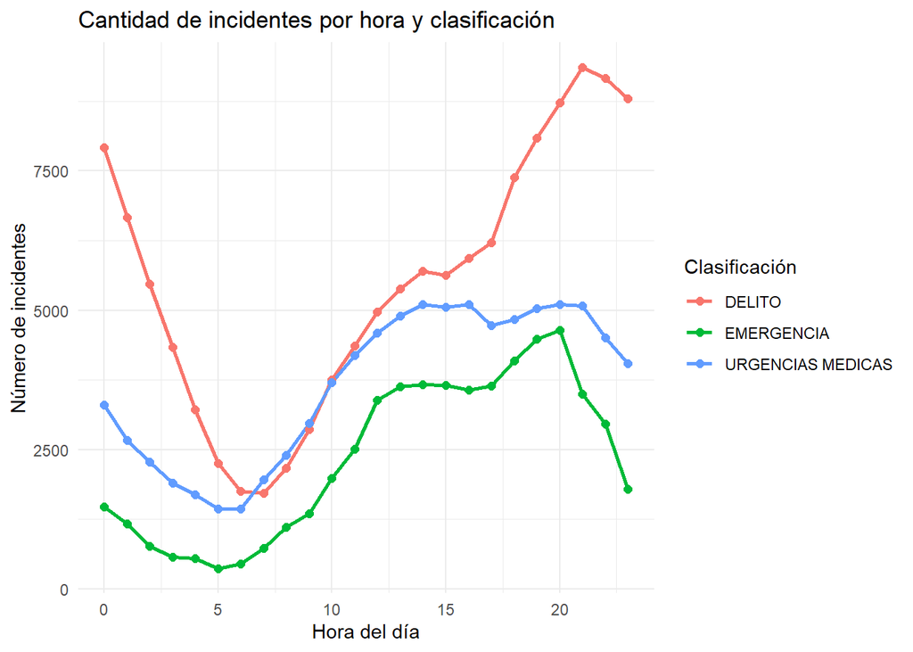

```
## Llamadas al 911 durante el segundo semestre de 2021
## # A tibble: 72 × 3
##     hora clasif            cantidad
##    <dbl> <chr>                <int>
##  1     0 DELITO                8927
##  2     0 EMERGENCIA            1316
##  3     0 URGENCIAS MEDICAS     3642
##  4     1 DELITO                7633
##  5     1 EMERGENCIA             944
##  6     1 URGENCIAS MEDICAS     3149
##  7     2 DELITO                5828
##  8     2 EMERGENCIA             750
##  9     2 URGENCIAS MEDICAS     2597
## 10     3 DELITO                4921
## 11     3 EMERGENCIA             676
```

[output cut: 40 more lines]

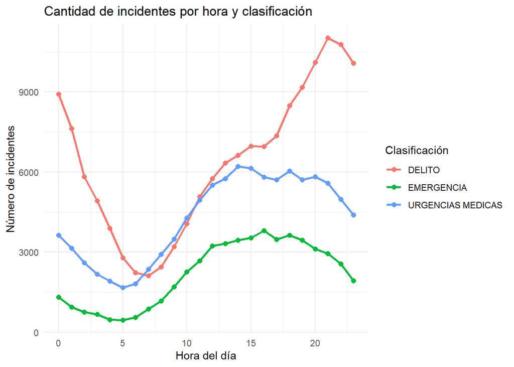

```
## Llamadas al 911 durante el primer semestre de 2022
## # A tibble: 72 × 3
##     hora clasif            cantidad
##    <dbl> <chr>                <int>
##  1     0 DELITO                5247
##  2     0 EMERGENCIA             763
##  3     0 URGENCIAS MEDICAS     2366
##  4     1 DELITO                4563
##  5     1 EMERGENCIA             634
##  6     1 URGENCIAS MEDICAS     1919
##  7     2 DELITO                3371
##  8     2 EMERGENCIA             522
##  9     2 URGENCIAS MEDICAS     1571
## 10     3 DELITO                2687
## 11     3 EMERGENCIA             352
```

[output cut: 40 more lines]

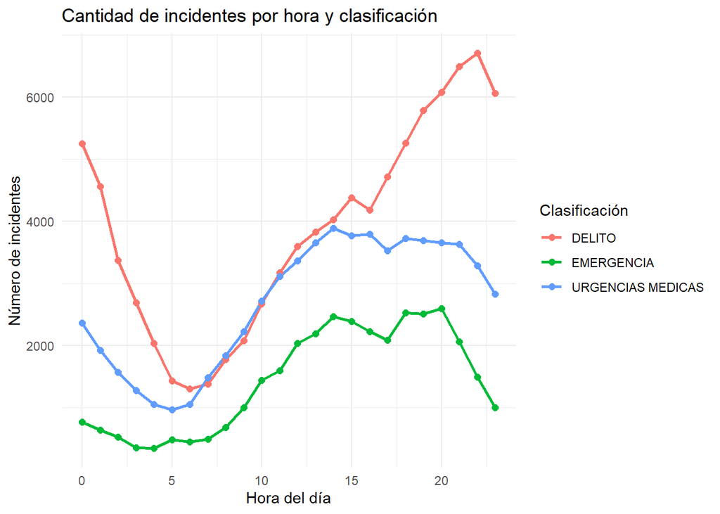

```r
# Cargar el archivo CSV
for (i in 1:3) {

  # Cargar el archivo CSV
  # Carga el archivo correspondiente
  if (i==1) {
    data <- read.csv("llamadas_911_2021_s1.csv", stringsAsFactors = FALSE)
    titulo ="Llamadas al 911 durante el primer semestre de 2021"
  } else {if (i==2){
    data <- read.csv("llamadas_911_2021_s2.csv", stringsAsFactors = FALSE)
    titulo ="Llamadas al 911 durante el segundo semestre de 2021"}
    else {
      data <- read.csv("llamadas_911_2022_s1.csv", stringsAsFactors = FALSE)
      titulo ="Llamadas al 911 durante el primer semestre de 2022"
    }

  }


  # Filtrar por las categorías solicitadas y convertir el campo hora_creacion a formato hora
  llamadas_filtradas <- data %>%
    filter(clasif %in% c("DELITO", "EMERGENCIA", "URGENCIAS MEDICAS")) %>%
   mutate(hora = hour(hms(hora_creacion)))

  # Contar los incidentes por hora y clasificación
  incidentes_por_hora_clasif <- llamadas_filtradas %>%
    group_by(hora, clasif) %>%
    summarise(cantidad = n(), .groups = "drop")

  # Imprimir los datos filtrados con los campos requeridos
  cat(titulo)
  cat("\n")
  print(n=50,incidentes_por_hora_clasif)
  cat("\n\n")



  # Crear la gráfica de incidentes por hora y clasificación
  library(ggplot2)
  print(
  ggplot(incidentes_por_hora_clasif, aes(x = hora, y = cantidad, color = clasif)) +
    geom_line(size = 1) +
    geom_point(size = 2) +
    labs(
      title = "Cantidad de incidentes por hora y clasificación ",
      x = "Hora del día",
      y = "Número de incidentes",
      color = "Clasificación"
     ) +
   theme_minimal()
  )


}
```

### Conclusiones ejercicio 3

Observando las gráficas para cada semestre del año 2021 y el primer semestre del 2022 como ya se comentó en la actividad 3.1 la cantidad de incidentes por hora se comportan de una manera muy similar en los tres semestres analizados, ahora con una mejor visualización con R Markdown.

## Ejercicio 4

Calcula el tiempo promedio entre la creación y cierre del incidente (usa fecha_creacion y fecha_cierre). Así mismo, determinar el tiempo mínimo y máximo.

```r
library(dplyr)
library(lubridate)
library(tidyr)
```

```r
for (i in 1:3) {

  # Cargar el archivo CSV
  # Carga el archivo correspondiente
  if (i==1) {
    data <- read.csv("llamadas_911_2021_s1.csv", stringsAsFactors = FALSE)
    titulo ="Llamadas al 911 durante el primer semestre de 2021"
  } else {if (i==2){
    data <- read.csv("llamadas_911_2021_s2.csv", stringsAsFactors = FALSE)
    titulo ="Llamadas al 911 durante el segundo semestre de 2021"}
    else {
      data <- read.csv("llamadas_911_2022_s1.csv", stringsAsFactors = FALSE)
      titulo ="Llamadas al 911 durante el primer semestre de 2022"
    }

  }


  # Verificar que las columnas necesarias existan
  if (all(c("fecha_creacion", "hora_creacion", "fecha_cierre", "hora_cierre") %in% colnames(data))) {

    # Crear las variables combinadas de fecha y hora para inicio y cierre
    data <- data %>%
     mutate(
       fecha_hora_creacion = dmy_hms(paste(fecha_creacion, hora_creacion)),
       fecha_hora_cierre = dmy_hms(paste(fecha_cierre, hora_cierre))
      )

    # Calcular el tiempo transcurrido en minutos
    data <- data %>%
      mutate(
        tiempo_transcurrido = as.numeric(difftime(fecha_hora_cierre, fecha_hora_creacion, units = "mins"))
      )
    # write.csv(data, "tiempo en minutos.csv", row.names = FALSE)
    # Mostrar las columnas para verificar que el calculo es correcto en etapa de prueba
    resultado <- data %>%
      select(fecha_creacion, hora_creacion, fecha_cierre, hora_cierre, tiempo_transcurrido)

  #  print(resultado)

    tiempos <- resultado %>%
      summarise(
        tiempo_promedio = mean(tiempo_transcurrido, na.rm = TRUE),
        tiempo_minimo = min(tiempo_transcurrido, na.rm = TRUE),
        tiempo_maximo = max(tiempo_transcurrido, na.rm = TRUE)
      )
    cat(titulo)
    cat("\n")
    print("Diferencia en minutos")
    print(tiempos)

    # Convertir los tiempos de minutos a horas
    tiempos <- tiempos %>%
      mutate(
        tiempo_promedio = (tiempo_promedio/60),
        tiempo_minimo = (tiempo_minimo/60),
        tiempo_maximo = (tiempo_maximo/60)
      )

    # Imprimir los resultados
    cat("\n")
    print("Diferencia en horas")

    print(tiempos)

    cat("\n\n\n")
   ########################


  } else {
    print("Las columnas necesarias no están presentes en el archivo.")
  }
}
```

```
## Llamadas al 911 durante el primer semestre de 2021
## [1] "Diferencia en minutos"
##   tiempo_promedio tiempo_minimo tiempo_maximo
## 1        127.2741     -2.016667      626023.5
##
## [1] "Diferencia en horas"
##   tiempo_promedio tiempo_minimo tiempo_maximo
## 1        2.121236   -0.03361111      10433.73
##
##
##
## Llamadas al 911 durante el segundo semestre de 2021
## [1] "Diferencia en minutos"
##   tiempo_promedio tiempo_minimo tiempo_maximo
## 1        146.4826     -55.93333      773171.5
##
## [1] "Diferencia en horas"
##   tiempo_promedio tiempo_minimo tiempo_maximo
## 1        2.441377    -0.9322222      12886.19
##
##
##
## Llamadas al 911 durante el primer semestre de 2022
## [1] "Diferencia en minutos"
##   tiempo_promedio tiempo_minimo tiempo_maximo
## 1        263.4538           0.3       1086041
##
## [1] "Diferencia en horas"
##   tiempo_promedio tiempo_minimo tiempo_maximo
## 1        4.390896         0.005      18100.69
```

```r
library(dplyr)
library(lubridate)
library(tidyr)
```

## Ejercicio 5

Determinar el porcentaje de llamadas que fueron clasificadas como “Falsa Alarma”.

```r
for (i in 1:3) {

  # Cargar el archivo CSV
    # Carga el archivo correspondiente
  if (i==1) {
    data <- read.csv("llamadas_911_2021_s1.csv", stringsAsFactors = FALSE)
    titulo ="Llamadas al 911 durante el primer semestre de 2021"
  } else {if (i==2){
            data <- read.csv("llamadas_911_2021_s2.csv", stringsAsFactors = FALSE)
            titulo ="Llamadas al 911 durante el segundo semestre de 2021"}
          else {
              data <- read.csv("llamadas_911_2022_s1.csv", stringsAsFactors = FALSE)
              titulo ="Llamadas al 911 durante el primer semestre de 2022"
          }

          }

  # Calcular el porcentaje de llamadas clasificadas como "Falsa Alarma"
  porcentaje_falsa_alarma <- data %>%
    summarise(
      total_llamadas = n(),
      falsas_alarmas = sum(clasif == "FALSA ALARMA", na.rm = TRUE),
      porcentaje = (falsas_alarmas / total_llamadas) * 100
   )

  # Imprimir el porcentaje de "Falsa Alarma"
  cat(titulo)
  cat("\n")
  print(porcentaje_falsa_alarma)
  cat("\n\n")
}
```

```
## Llamadas al 911 durante el primer semestre de 2021
##   total_llamadas falsas_alarmas porcentaje
## 1         650278            495 0.07612129
##
##
## Llamadas al 911 durante el segundo semestre de 2021
##   total_llamadas falsas_alarmas   porcentaje
## 1         630697              6 0.0009513285
##
##
## Llamadas al 911 durante el primer semestre de 2022
##   total_llamadas falsas_alarmas   porcentaje
## 1         390061              3 0.0007691105
```

### Conclusiones ejercicio 5

Curiosamente las cifras continúan siendo parecidas en el segundo semestre de 2021 y el primero de 2022 aunque el total de llamadas descendió significativamente en 2022. Ahora visualizadas con HTML.